# High School Seniors t Test

```r
library(tidyverse)
library(DT)
library(pander)
library(readr)
library(mosaic)

HSS <- read_csv("../../Data/HighSchoolSeniors.csv")
#Remember: select "Session, Set Working Directory, To Source File Location", and then play this R-chunk into your console to read the HSS data into R.
```

### Background

$$H_0: \mu_\text{Women} = \mu_\text{Men}$$
$$H_a: \mu_\text{Women} \gt \mu_\text{Men}$$
The level of significance will be set at:
$$\alpha = .05$$

In this situation, it seems appropriate to perform a two sample independent t-test. Our data comes from the a US Census that was conducted, therefore we can assume that it is a simple random sample. Each group also contains a sample size greater than 30 so because of the central limit theorem we can be sure that the distribution of sample means is normal. With both of these requirements met, we can move on with our study.

### Analysis

We were able to run this analysis using the independent t-test function in R and building some visual representations of the data. What was found is that the data is very strongly right-skewed in both categories, but mostly with the males. Most females text more than the males do based on the median, however the male mean is much higher because of some extremely large outliers up in the 10,000s. To really build an accurate representation with a t-test, we would need to remove these outliers, so the data was filtered to points only below 5000 text-messages sent yesterday. This made the t-test, and even the graphs, much more meaningful.

```r
yeah <- HSS %>%
  na.omit(c(Text_Messages_Sent_Yesterday, Gender)) %>%
  filter(Text_Messages_Sent_Yesterday <5000)

no <- HSS %>%
  na.omit(c(Text_Messages_Sent_Yesterday, Gender))

pander(favstats(Text_Messages_Sent_Yesterday ~ Gender, data=no)[,-10], caption='See Stats Without Filter')
```

See Stats Without Filter

| Gender | min | Q1 | median | Q3 | max | mean | sd | n |
| --- | --- | --- | --- | --- | --- | --- | --- | --- |
| Female | 0 | 12 | 35 | 100 | 1000 | 73.47 | 120.3 | 163 |
| Male | 0 | 8 | 20 | 50 | 10000 | 147.5 | 875 | 163 |

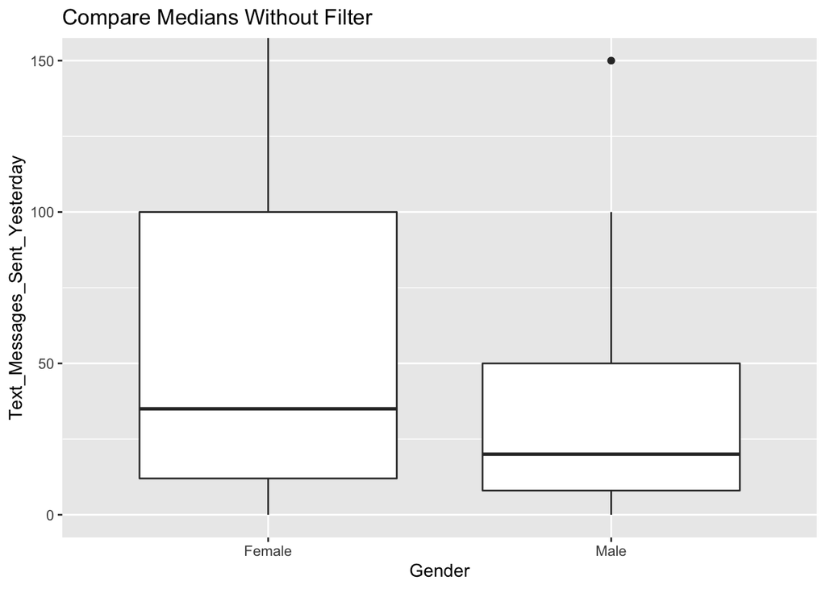

```r
ggplot(no, aes(x=Gender, y=Text_Messages_Sent_Yesterday)) +
geom_boxplot() +
coord_cartesian(ylim = c(0, 150)) +
labs(title = "Compare Medians Without Filter")
```

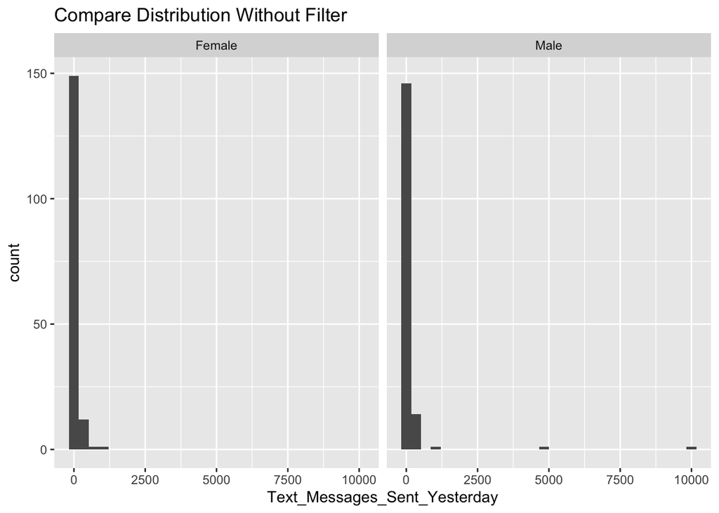

```r
ggplot(no, aes(x=Text_Messages_Sent_Yesterday)) +
  geom_histogram() +
  facet_wrap(~Gender) +
  labs(title = "Compare Distribution Without Filter")
```

```r
pander(favstats(Text_Messages_Sent_Yesterday ~ Gender, data=yeah)[,-10], caption='See Stats With Filter')
```

See Stats With Filter

| Gender | min | Q1 | median | Q3 | max | mean | sd | n |
| --- | --- | --- | --- | --- | --- | --- | --- | --- |
| Female | 0 | 12 | 35 | 100 | 1000 | 73.47 | 120.3 | 163 |
| Male | 0 | 8 | 20 | 50 | 1000 | 56.12 | 113.4 | 161 |

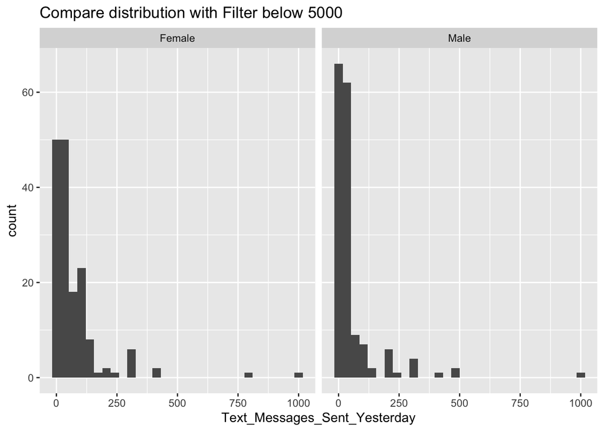

```r
ggplot(yeah, aes(x=Text_Messages_Sent_Yesterday)) +
  geom_histogram() +
  facet_wrap(~Gender) +
  labs(title = "Compare distribution with Filter below 5000")
```

```r
pander(t.test(Text_Messages_Sent_Yesterday ~ Gender, data = yeah, mu = 0, alternative = "greater", conf.level = 0.95))
```

Welch Two Sample t-test: `Text_Messages_Sent_Yesterday` by `Gender` (continued below)

| Test statistic | df | P value | Alternative hypothesis |
| --- | --- | --- | --- |
| 1.335 | 321.3 | 0.09135 | greater |

| mean in group Female | mean in group Male |
| --- | --- |
| 73.47 | 56.12 |

### Interpretation

Using R programming we were able to run a t-test. The results are displayed above. Despite the means between the two groups appearing to be very different, the P-value comes out to be .09135 which is not less than our level of significance, so we do not have enough evidence to prove that there is a significant difference between males and females texting. We fail to reject the null. This means that there is not sufficient evidence to prove that high school girls text more than high school boys and it would be incorrect, for now, to perpetuate this sort of stereotype. However, future studies with more data could potentially prove otherwise, or if for some reason we chose to raise our alpha to .1, then we could possibly reject the null in those studies.

This is a good example of why it is important to use a t-test rather than simply finding and comparing the means of two groups. A human would likely look at the two numbers and say that they are very different but running a t-test gives us the ability to objectively say how different they really are.